# **Discipline Report**

SID:** 480139690

*‘Predicting the presence of T-cell mediated rejection (TCMR) based on recipients’ gene characteristics’*

# **Executive Summary**

## **Aim and Background**

Antibody mediated rejection remains an important barrier to optimal long-term outcomes after kidney transplantation(Vasishta S 2018). In this study, we want to figure out **How to predict presence of T-cell mediated rejection (TCMR) based on recipients’ gene characteristics?**

We will use **GSE131179** containg kidney allograft recipients RNA-seq expression values, first apply differential gene analysis between **TCMR group** and **Normal group** using Fitted Linear Model with empirical Bayes method. After that, a SVM classifer has been used to predict rejection based on recipients’ gene.

Raw read count data has already been normalised with Fragments Per Kilobase of transcript per Million (FPKM). However, to minimise variance difference among different samples, we normalised data using $log_2$ transformation, with 1 plus in case original expression value is 0. After normalising, boxplots shows there is still a few samples demonstrat slightly disparate distribution. We consider it as $\color{RED}{\text{Potential Shortcoming 1}}$

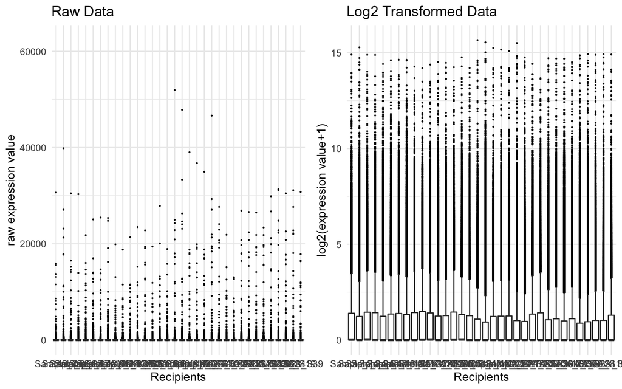

## **Differential gene expression analysis**

### **Key Approach: Contrast comparison using Fitted Linear Model**

To identify differential genes, we perform **Contrast Comparison** to each gene between **TCMR** group and **Normal** group. In that case, we use fitted linear model to estimate the variability in the data.

A hypothesis test was performed on $\beta_g$, the coefficient of each gene, where $g\in\{0,1,\cdots,60466\}$. Each test has the following form:

1. **Hypotheses:**
- $H_0$: There are identical gene expression values for same gene between two groups. That is, $Y_{kg} = \mu + \epsilon_{kg}, g = 1,...,60466, k = 1,2$
- $H_1$: There is at least one differencial gene between two groups. That is, $Y_{kg} = \mu + \alpha_k + \epsilon_{kg}, g = 1,...,60466, k = 1,2$
2. **Test statistic:**

We use **moderated t-statistic** to perform significance analysis given by:

$$\tilde{t_{gk}}=\frac{\hat{\beta_{gk}}}{u_{gk}\tilde{s_g}}$$

Under $H_0$, we have that $T\sim t_{n-2}$ where 2 is rank, because we have two groups to compare.

The linear model for gene g has residual variance ${\sigma_g}^2$ with sample value ${s_g}^2$ and degrees of freedom $d_g$.

3. **Procedure Outline:**
- Create **design matrix** includes the independent coefficient for each sample in two groups, say **$X$**;
- Create **contrast matrix** create contrasts of these fitted linear models to make all contrast comparisons between the two groups, say $C$.
- Fits a linear model. This linear model is fitted to the expression data for each probe.
- After using **contrast.fit** to estimate contrast for each gene. Our questions becomes *‘find the top significant sample contrast’*. The covariance matrix of the estimated $\beta_g$ is ${\sigma_g}^2C^T(X^TX)^{-1}C$ and the $s_g$ is the square-roots of diagonal elements of $C^T(X^TX)^{-1}C$.
- The **eBayes()** uses an empirical Bayes method to moderate the standard errors of the estimated log-fold changes. This results generates more stable inference and improved power, decrease Type II error(Smyth 2004).The posterior values for the residual variances are given by:
  $$\tilde{s_{g}}^2=\frac{d_0s_0^2}{d_0+d_g}$$

Where $d_g$ is the residual degrees of freedom for the gth gene.

- Using coefficient $\beta_g$ and unscaled standard deviations $s_g$, we can calculate **p-value** and order genes by significance. A list of top genes differential expressed in **TCMR** group versus **Normal** group can be obtained from topTable, which use moderated t-statistic to perform significance analysis.

## **Visualise Differentially Expressed Gene**

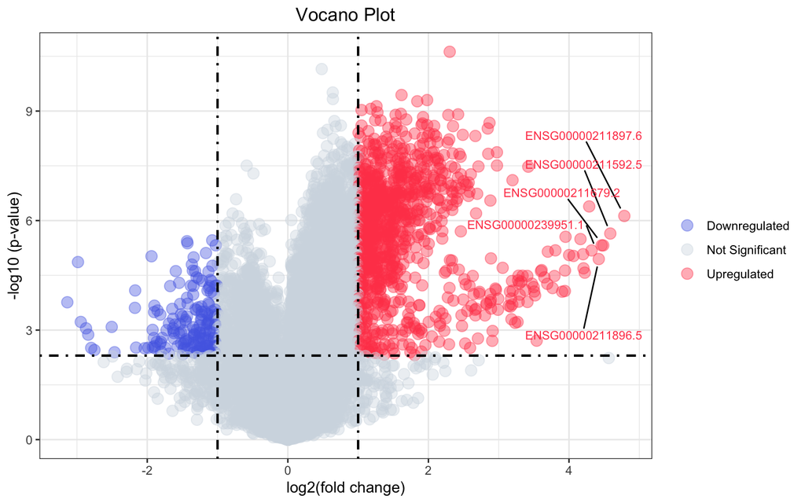

We can get a basic overview of gene expression difference using **Vocano plot**. Here we can see there are much more upregulated genes than downregulated genes, which means the final gene expression value between **two groups are not in the same order of magnitude**. That might cause biased result in later analysis, we consider it as $\color{RED}{\text{Potential Shortcoming 2}}$.

## **Using Shiny APP to Select Minimum Number of Important Gene**

Shiny app address: “https://aliama-bi.shinyapps.io/480139690_app/”

Importance of gene is ordered by **p-value** calculated in previouse Contrast Comparison model. Next, we use interactive app generate by package ‘shiny’ (Winston 2020) to explore minimum number of important gene needed to classify two groups.

User can select number of gene between 50 - 200 using slidebar, and investigate clustering image map (CIM) to see if it successfully distinguish two groups. We find with only **top 50 important gene**, we can easily tell difference of gene expression value between these two groups.

Below is a clustering Image Map (CIM) used to visulise gene clustering observation between two groups using top 50 important genes.

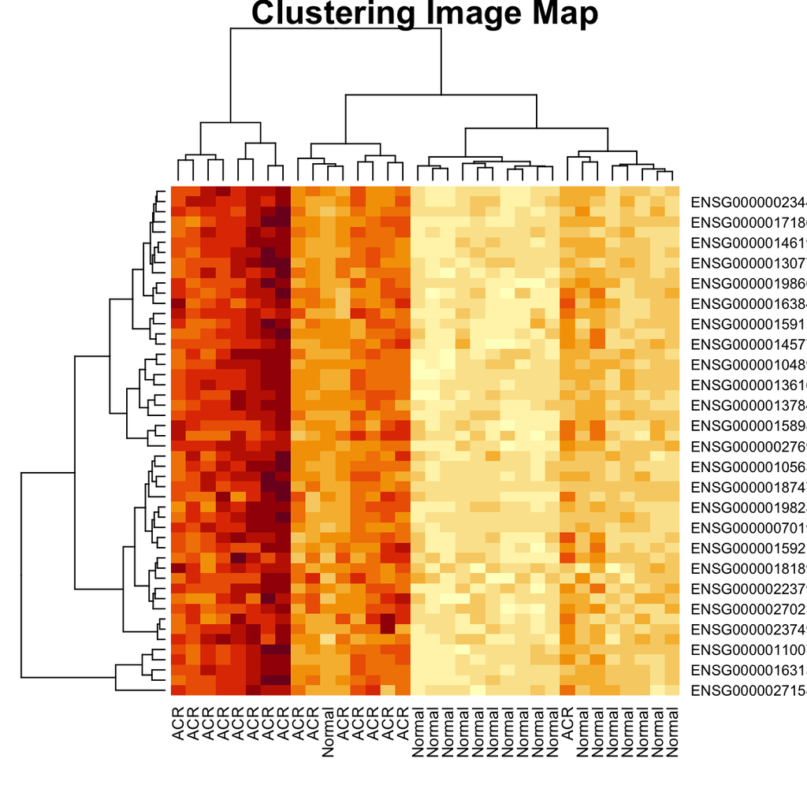

```r
sig50 <- rownames(fit2$coefficients[order(fit2$F, decreasing = TRUE)[1:50], -1])
temp = gse[sig50, ]
colnames(temp) = groupname
heatmap(temp, main = "Clustering Image Map", cex.main = 5)
```

```r
sig200 <- rownames(fit2$coefficients[order(fit2$F, decreasing = TRUE)[1:200], -1])
csv_file_feader = groupname
csv_file = gse[sig200, ]
colnames(csv_file) = csv_file_feader
# write.csv(csv_file, 'GSE131179_expression_matrix.csv')
```

## **Generate Machine Learning Classifier**

Using Top 50 important Genes, we next build a classifier for predicting kidney transplant rejection based on recipients’ gene characteristics.

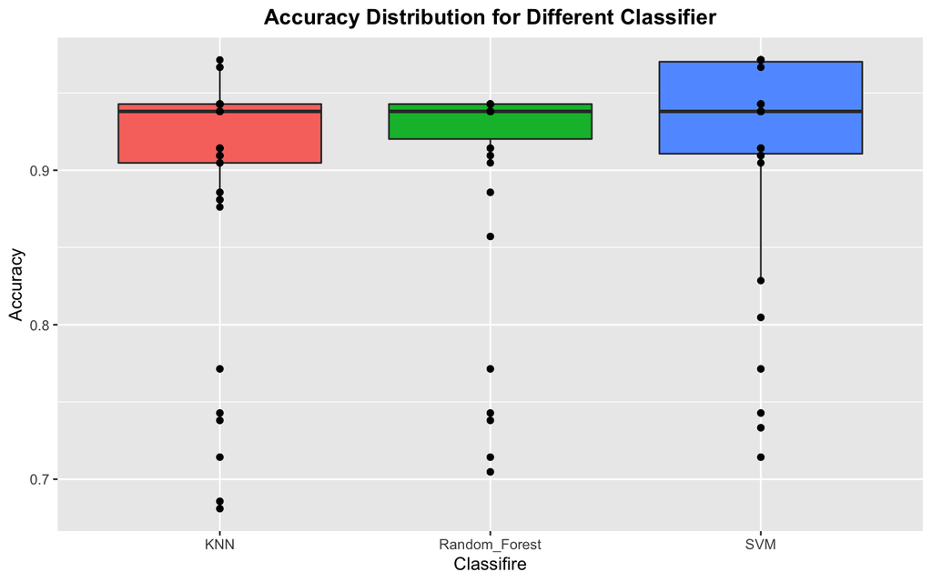

## **Potential Shortcoming**

- For first potential shortcoming, to keep all samples value has similar distribution, we can consider remove some really abnormal samples.
- For second potential shortcoming, we can check if there is rRNA or other types of RNA affect their quality.

## **References**

- Vasishta S. Tatapudi and Bonnie E. Lonze (March 31st 2018). Diagnosis, Treatment, and Outcomes of Antibody-Mediated Rejection in Kidney Transplantation, Organ Donation and Transplantation - Current Status and Future Challenges, Georgios Tsoulfas, IntechOpen, DOI: 10.5772/intechopen.75770.
- Mueller FB, Yang H, Lubetzky M, Verma A et al. Landscape of innate immune system transcriptome and acute T cell-mediated rejection of human kidney allografts. JCI Insight 2019 Jul 11;4(13). PMID: 31292297
- Ritchie, M.E., Phipson, B., Wu, D., Hu, Y., Law, C.W., Shi, W., and Smyth, G.K. (2015). limma powers differential expression analyses for RNA-sequencing and microarray studies. Nucleic Acids Research 43(7), e47.
- Smyth, G. K. 2004. “Linear Models and Empirical Bayes Methods for Assessing Differential Expression in Microarray Experiments.” Stat Appl Genet Mol Biol 3 (1):Article 3.
- Winston Chang, Joe Cheng, JJ Allaire, Yihui Xie and Jonathan McPherson (2020). shiny: Web Application Framework for R. R package version 1.4.0.2. https://CRAN.R-project.org/package=shiny